# Day 1. Data import and Data Visualization

Nicholas Michalak

6/25/2017

# install prerequisite packages

```r
# character vector of packages you'll need for your whole analysis
needed_packages <- c("tidyverse", "stringr", "haven", "readxl")

# source custom function
source("custom_functions/install_needed_pkgs.R")

# install needed packages
install_needed_pkgs(needed_packages = needed_packages)
```

```
## [[1]]
##  [1] "dplyr"     "purrr"     "readr"     "tidyr"     "tibble"
##  [6] "ggplot2"   "tidyverse" "stats"     "graphics"  "grDevices"
## [11] "utils"     "datasets"  "methods"   "base"
##
## [[2]]
##  [1] "stringr"   "dplyr"     "purrr"     "readr"     "tidyr"
##  [6] "tibble"    "ggplot2"   "tidyverse" "stats"     "graphics"
## [11] "grDevices" "utils"     "datasets"  "methods"   "base"
##
## [[3]]
##  [1] "haven"     "stringr"   "dplyr"     "purrr"     "readr"
##  [6] "tidyr"     "tibble"    "ggplot2"   "tidyverse" "stats"
## [11] "graphics"  "grDevices" "utils"     "datasets"  "methods"
## [16] "base"
##
## [[4]]
##  [1] "readxl"    "haven"     "stringr"   "dplyr"     "purrr"
##  [6] "readr"     "tidyr"     "tibble"    "ggplot2"   "tidyverse"
## [11] "stats"     "graphics"  "grDevices" "utils"     "datasets"
## [16] "methods"   "base"
```

# Basic piping

## `x %>% f` is equivalent to `f(x)`

```r
# 10 values drawn from normal distribution, mean = 0, sd = 1
# set randomizer seed first so results can be reproduced
set.seed(12)
ten_rnorm_x <- rnorm(n = 10, mean = 0, sd = 1)

# mean
# with pipes
ten_rnorm_x %>% mean(.)
```

```
## [1] -0.4672139
```

```r
# without pipes
mean(ten_rnorm_x)
```

```
## [1] -0.4672139
```

## `x %>% f(y)` is equivalent to `f(x, y)`

```r
# create new variable with r ~ 0.5 correlation with first variable
# set randomizer seed first so results can be reproduced
set.seed(123)
ten_rnorm_y <- ten_rnorm_x * 0.5 + rnorm(n = 10, mean = 0, sd = 1)

# correlation between five_rnorm_x and five_rnorm_y
# with pipes
ten_rnorm_x %>% cor(ten_rnorm_y)
```

```
## [1] 0.3858978
```

```r
# without pipes
cor(ten_rnorm_x, ten_rnorm_y)
```

```
## [1] 0.3858978
```

## `x %>% f %>% g %>% h` is equivalent to `h(g(f(x)))`

```r
# extract numbers from characters
# mean center those numbers
# convert list (the result of the scale function) to a number
# with pipes
c("s1z", "n2w", "o3q", "g4s", "d5a") %>%
  parse_number() %>%
  scale(center = TRUE, scale = FALSE) %>%
  parse_number()
```

```
## [1] -2 -1  0  1  2
```

```r
# without pipes
parse_number(
  scale(
    parse_number(
      c("s1z", "n2w", "o3q", "g4s", "d5a")
      ), center = TRUE, scale = FALSE
    )
  )
```

```
## [1] -2 -1  0  1  2
```

## a more practical example

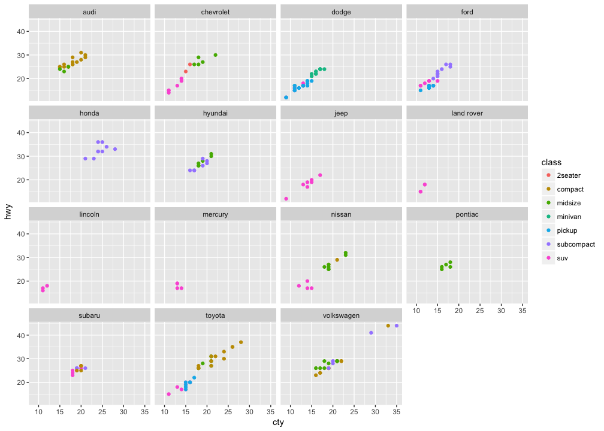

```r
# using the mpg dataset (?mpg)
# filter out cars that have less than 6 litre engine displacement
# and then select only manufacturer, class, city, and highway
# and then, finally, plot hwy on cty, coloring the points by class and
# faceting the plots by manufacturer
mpg %>%
  filter(displ < 6) %>%
  select(manufacturer, class, cty, hwy) %>%
  ggplot(aes(x = cty, y = hwy, color = class)) +
  geom_point() +
  facet_wrap(~ manufacturer)
```

# classic example: Anscombe’s Quartet

## fit linear rgeression for first set

```r
model_1 <- lm(y1 ~ x1, data = anscombe)

# summarize
summary(model_1)
```

```
##
## Call:
## lm(formula = y1 ~ x1, data = anscombe)
##
## Residuals:
##      Min       1Q   Median       3Q      Max
## -1.92127 -0.45577 -0.04136  0.70941  1.83882
##
## Coefficients:
##             Estimate Std. Error t value Pr(>|t|)
## (Intercept)   3.0001     1.1247   2.667  0.02573 *
## x1            0.5001     0.1179   4.241  0.00217 **
## ---
## Signif. codes:  0 '***' 0.001 '**' 0.01 '*' 0.05 '.' 0.1 ' ' 1
##
## Residual standard error: 1.237 on 9 degrees of freedom
## Multiple R-squared:  0.6665, Adjusted R-squared:  0.6295
## F-statistic: 17.99 on 1 and 9 DF,  p-value: 0.00217
```

## fit linear rgeression for second set

```r
model_2 <- lm(y2 ~ x2, data = anscombe)

# summarize
summary(model_2)
```

```
##
## Call:
## lm(formula = y2 ~ x2, data = anscombe)
##
## Residuals:
##     Min      1Q  Median      3Q     Max
## -1.9009 -0.7609  0.1291  0.9491  1.2691
##
## Coefficients:
##             Estimate Std. Error t value Pr(>|t|)
## (Intercept)    3.001      1.125   2.667  0.02576 *
## x2             0.500      0.118   4.239  0.00218 **
## ---
## Signif. codes:  0 '***' 0.001 '**' 0.01 '*' 0.05 '.' 0.1 ' ' 1
##
## Residual standard error: 1.237 on 9 degrees of freedom
## Multiple R-squared:  0.6662, Adjusted R-squared:  0.6292
## F-statistic: 17.97 on 1 and 9 DF,  p-value: 0.002179
```

## fit linear rgeression for third set

```r
model_3 <- lm(y3 ~ x3, data = anscombe)

# summarize
summary(model_3)
```

```
##
## Call:
## lm(formula = y3 ~ x3, data = anscombe)
##
## Residuals:
##     Min      1Q  Median      3Q     Max
## -1.1586 -0.6146 -0.2303  0.1540  3.2411
##
## Coefficients:
##             Estimate Std. Error t value Pr(>|t|)
## (Intercept)   3.0025     1.1245   2.670  0.02562 *
## x3            0.4997     0.1179   4.239  0.00218 **
## ---
## Signif. codes:  0 '***' 0.001 '**' 0.01 '*' 0.05 '.' 0.1 ' ' 1
##
## Residual standard error: 1.236 on 9 degrees of freedom
## Multiple R-squared:  0.6663, Adjusted R-squared:  0.6292
## F-statistic: 17.97 on 1 and 9 DF,  p-value: 0.002176
```

## fit linear rgeression for fourth set

```r
model_4 <- lm(y4 ~ x4, data = anscombe)

# summarize
summary(model_4)
```

```
##
## Call:
## lm(formula = y4 ~ x4, data = anscombe)
##
## Residuals:
##    Min     1Q Median     3Q    Max
## -1.751 -0.831  0.000  0.809  1.839
##
## Coefficients:
##             Estimate Std. Error t value Pr(>|t|)
## (Intercept)   3.0017     1.1239   2.671  0.02559 *
## x4            0.4999     0.1178   4.243  0.00216 **
## ---
## Signif. codes:  0 '***' 0.001 '**' 0.01 '*' 0.05 '.' 0.1 ' ' 1
##
## Residual standard error: 1.236 on 9 degrees of freedom
## Multiple R-squared:  0.6667, Adjusted R-squared:  0.6297
## F-statistic:    18 on 1 and 9 DF,  p-value: 0.002165
```

## plot all four sets

```r
# start with anscombe dataset that comes with R
# select variables x1 through x4b n
# gather columns into pairs: name the variable "set" and the value "x"
# write over the "set" variable with a new variable that replaces "x" with ""
# save result as "anscombe_x"
(anscombe_x <-
anscombe %>%
  select(x1:x4) %>%
  gather(set, x) %>%
  mutate(set = str_replace(string = set, pattern = "x", replacement = "")) %>%
  as_tibble())
```

```
## # A tibble: 44 x 2
##      set     x
##    <chr> <dbl>
##  1     1    10
##  2     1     8
##  3     1    13
##  4     1     9
##  5     1    11
##  6     1    14
##  7     1     6
##  8     1     4
##  9     1    12
## 10     1     7
## # ... with 34 more rows
```

```r
# start with anscombe dataset that comes with R
# select variables y1 through y4
# gather columns into pairs: name the variable "set" and the value "y"
# write over the "set" variable with a new variable that replaces "y" with ""
# save result as "anscombe_y"
(anscombe_y <-
anscombe %>%
  select(y1:y4) %>%
  gather(set, y) %>%
  mutate(set = str_replace(string = set, pattern = "x", replacement = "")) %>%
  as_tibble())
```

```
## # A tibble: 44 x 2
##      set     y
##    <chr> <dbl>
##  1    y1  8.04
##  2    y1  6.95
##  3    y1  7.58
##  4    y1  8.81
##  5    y1  8.33
##  6    y1  9.96
##  7    y1  7.24
##  8    y1  4.26
##  9    y1 10.84
## 10    y1  4.82
## # ... with 34 more rows
```

```r
# bind those datasets above by columns
# however, remove the set variable from the anscombe_y dataset
(anscombe_long <- bind_cols(anscombe_x, anscombe_y %>%
                             select(-set)))
```

```
## # A tibble: 44 x 3
##      set     x     y
##    <chr> <dbl> <dbl>
##  1     1    10  8.04
##  2     1     8  6.95
##  3     1    13  7.58
##  4     1     9  8.81
##  5     1    11  8.33
##  6     1    14  9.96
##  7     1     6  7.24
##  8     1     4  4.26
##  9     1    12 10.84
## 10     1     7  4.82
## # ... with 34 more rows
```

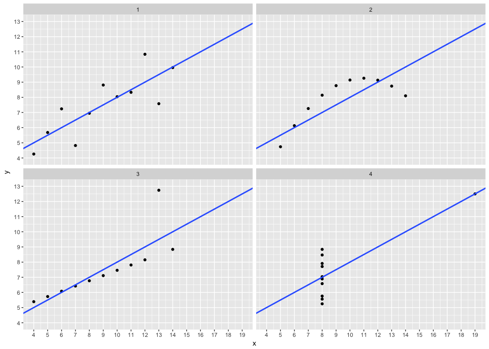

```r
anscombe_long %>%
  ggplot(aes(x = x, y = y)) +
  geom_point() +
  stat_smooth(method = "lm", se = FALSE, fullrange = TRUE) +
  scale_x_continuous(breaks = 3:20, limits = c(3, 20)) +
  scale_y_continuous(breaks = 3:13, limits = c(3, 13)) +
  coord_cartesian(xlim = c(4, 19), ylim = c(4, 13)) +
  facet_wrap(~ set)
```

# modern example: Datasaurus

> Matejka, J., & Fitzmaurice, G. (2017, May). [Same stats, different graphs: Generating datasets with varied appearance and identical statistics through simulated annealing](https://www.autodeskresearch.com/publications/samestats). In Proceedings of the 2017 CHI Conference on Human Factors in Computing Systems (pp. 1290-1294). ACM.

## see it

```r
(datasaurus <- "example_tidy_data/datasaurus_dozen.tsv" %>%
  read_tsv())
```

```
## # A tibble: 1,846 x 3
##    dataset       x       y
##      <chr>   <dbl>   <dbl>
##  1    dino 55.3846 97.1795
##  2    dino 51.5385 96.0256
##  3    dino 46.1538 94.4872
##  4    dino 42.8205 91.4103
##  5    dino 40.7692 88.3333
##  6    dino 38.7179 84.8718
##  7    dino 35.6410 79.8718
##  8    dino 33.0769 77.5641
##  9    dino 28.9744 74.4872
## 10    dino 26.1538 71.4103
## # ... with 1,836 more rows
```

## describe it

```r
datasaurus$dataset %>%
  unique() %>%
  map_df(function(set) {

    r <- datasaurus %>%
      filter(dataset == set) %>%
      with(., cor(x, y))

    datasaurus %>%
      filter(dataset == set) %>%
      summarise(n = n(),
                mean_x = mean(x),
                sd_x = sd(x),
                mean_y = mean(y),
                sd_y = sd(y),
                se = ) %>%
      mutate(r_xy = r,
             dataset = set) %>%
      select(dataset, n, everything(.))

  })
```

```
## # A tibble: 13 x 7
##       dataset     n   mean_x     sd_x   mean_y     sd_y        r_xy
##         <chr> <int>    <dbl>    <dbl>    <dbl>    <dbl>       <dbl>
##  1       dino   142 54.26327 16.76514 47.83225 26.93540 -0.06447185
##  2       away   142 54.26610 16.76982 47.83472 26.93974 -0.06412835
##  3    h_lines   142 54.26144 16.76590 47.83025 26.93988 -0.06171484
##  4    v_lines   142 54.26993 16.76996 47.83699 26.93768 -0.06944557
##  5    x_shape   142 54.26015 16.76996 47.83972 26.93000 -0.06558334
##  6       star   142 54.26734 16.76896 47.83955 26.93027 -0.06296110
##  7 high_lines   142 54.26881 16.76670 47.83545 26.94000 -0.06850422
##  8       dots   142 54.26030 16.76774 47.83983 26.93019 -0.06034144
##  9     circle   142 54.26732 16.76001 47.83772 26.93004 -0.06834336
## 10   bullseye   142 54.26873 16.76924 47.83082 26.93573 -0.06858639
## 11   slant_up   142 54.26588 16.76885 47.83150 26.93861 -0.06860921
## 12 slant_down   142 54.26785 16.76676 47.83590 26.93610 -0.06897974
## 13 wide_lines   142 54.26692 16.77000 47.83160 26.93790 -0.06657523
```

## plot it

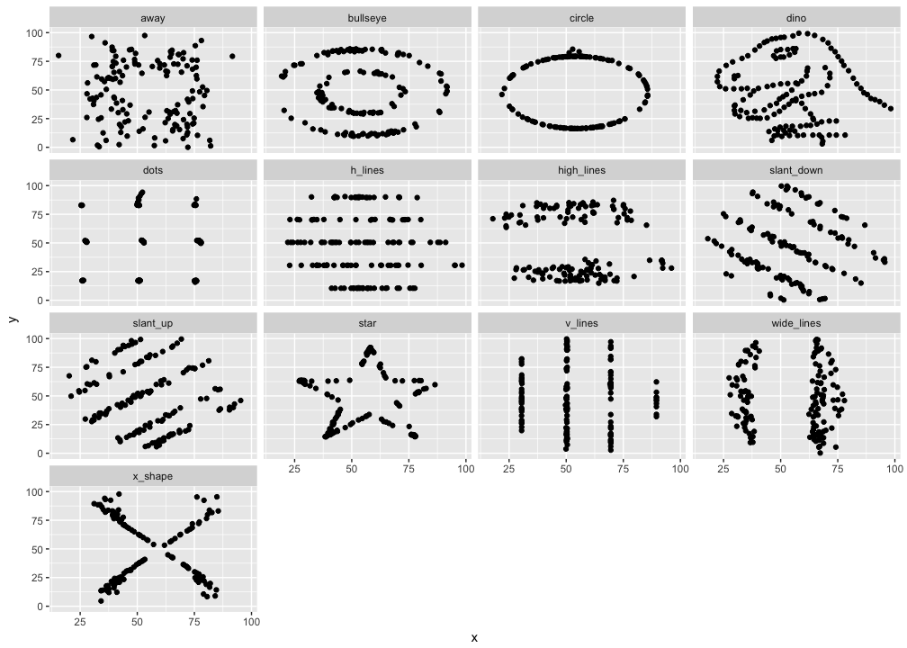

```r
datasaurus %>%
  ggplot(aes(x = x, y = y)) +
  geom_point() +
  facet_wrap(~ dataset)
```

# psychology example 1

> (Adapted from Maxwell & Delaney, 1990, p 300, quest #9) A clinical psychologist wants to compare three types of therapy for snake phobia. However, she does not believe that one type of therapy is necessarily best for everyone; the best therapy may depend on the severity level of the client’s phobia. Undergraduate students enrolled in an introductory psychology course were given a Fear Inventory to screen out subjects showing no fear of snakes. Those displaying some degree of snake phobia were classified as either mildly or severely phobic. Subjects were then randomly assigned to one of three treatment conditions: systematic desensitization, implosive therapy, or insight therapy. The following data are from a well-accepted phobia scale (higher scores indicate less phobia). You don’t need to know anything about the conceptual differences between these three therapies or the phobia scale to answer the following questions. To save time, no need to check assumptions for this problem set but don’t skip this step when you analyze real data in your research.

```r
# source example data
source("example_tidy_data/snake_phobia.R")

# view descriptives for snake therapy data
snk_thrpy_desc
```

```
## # A tibble: 6 x 8
## # Groups:   therapy [?]
##           therapy severity n_cell mean_phobia sd_phobia se_phobia   t_crit
##             <chr>    <chr>  <int>       <dbl>     <dbl>     <dbl>    <dbl>
## 1 Desensitization     Mild      8      13.250  1.669046 0.5900968 2.364624
## 2 Desensitization   Severe      8      11.125  3.181981 1.1250000 2.364624
## 3       Implosion     Mild      8      15.375  1.407886 0.4977629 2.364624
## 4       Implosion   Severe      8       6.500  3.891382 1.3758114 2.364624
## 5         Insight     Mild      8      12.875  1.642081 0.5805632 2.364624
## 6         Insight   Severe      8       9.250  3.370036 1.1914877 2.364624
## # ... with 1 more variables: moe_phobia <dbl>
```

## plot means from table of descriptives

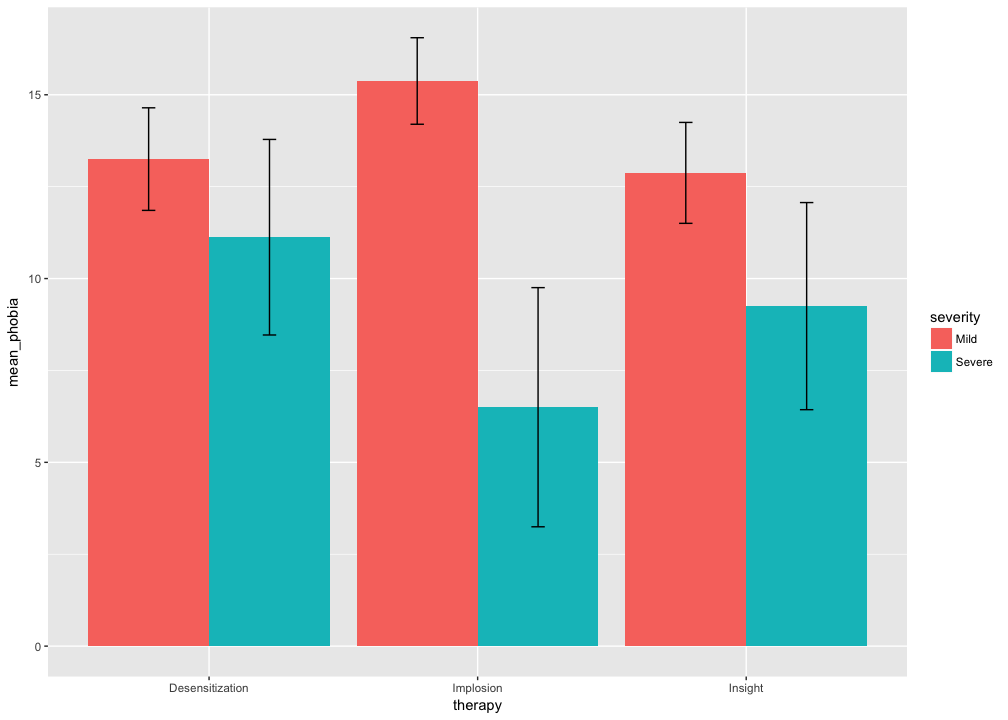

```r
ggplot(data = snk_thrpy_desc, aes(x = therapy, y = mean_phobia, fill = severity)) +
  geom_bar(stat = "identity", position = position_dodge(width = 0.9)) +
  geom_errorbar(mapping = aes(ymin = mean_phobia - moe_phobia, ymax = mean_phobia + moe_phobia), position = position_dodge(width = 0.9), width = 0.1)
```

## plot means from raw data

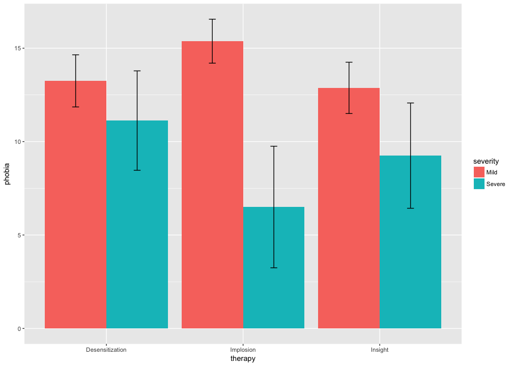

```r
ggplot(data = snakes_therapy, aes(x = therapy, y = phobia, fill = severity)) +
  stat_summary(fun.data = "mean_cl_normal", geom = "bar", position = position_dodge(width = 0.9)) +
  stat_summary(fun.data = "mean_cl_normal", geom = "errorbar", position = position_dodge(width = 0.9), width = 0.1)
```

# psychology example 2

> adapted from figure 1 from Tybur et al. (2016)
- The scatterplot displays the relationship between national parasite stress and traditionalism (r = 0.70). Each data point [labeled with a two-letter country code (abbreviations defined in Table 1)] represents a nation’s mean traditionalism, controlling for sample demographic characteristics (age and sex).
- To facilitate visual interpretation of results (Figs. 1–3), we added a constant to each nation’s parasite stress score so that the lowest scoring country (Canada) had a value of zero.

```r
# source example data
source("example_tidy_data/tybur_et_al_fig_1.R")
```

```r
# view data for plot
tybur_et_al_fig1
```

```
## # A tibble: 30 x 4
## # Groups:   country [30]
##        country histpath traditionalism hist_path_rscld
##         <fctr>    <dbl>          <dbl>           <dbl>
##  1      Israel     0.52       2.790726            1.83
##  2   Singapore     0.31       2.715984            1.62
##  3     Belgium    -1.00       1.926433            0.31
##  4      Serbia    -0.23       1.890731            1.08
##  5       Spain    -0.05       1.632627            1.26
##  6   Australia    -0.25       1.944385            1.06
##  7    Slovakia    -1.00       2.755881            0.31
##  8      France    -0.46       1.972309            0.85
##  9 New Zealand    -0.98       2.110723            0.33
## 10     Denmark    -0.98       1.352026            0.33
## # ... with 20 more rows
```

## scatterplot with 95% confidence ribbons country labels

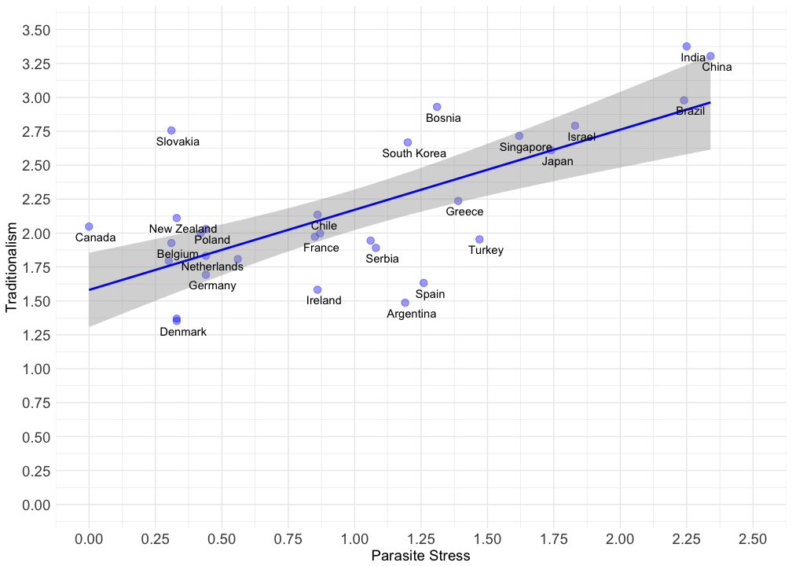

```r
ggplot(data = tybur_et_al_fig1, aes(x = hist_path_rscld, y = traditionalism, label = country)) +
  geom_point(size = 3, alpha = 0.4, color = "blue") +
  geom_smooth(method = "lm", color = "blue") +
  scale_x_continuous(breaks = seq(0, 2.5, 0.25), limits = c(0, 2.5)) +
  scale_y_continuous(breaks = seq(0, 3.5, 0.25), limits = c(0, 3.5)) +
  geom_text(check_overlap = TRUE, nudge_x = 0.025, nudge_y = -0.075) +
  labs(x = "Parasite Stress", y = "Traditionalism") +
  theme_minimal() +
  theme(axis.title.x = element_text(size = 14),
        axis.text.x = element_text(size = 14),
        axis.title.y = element_text(size = 14),
        axis.text.y = element_text(size = 14))
```

## compare this to published figure

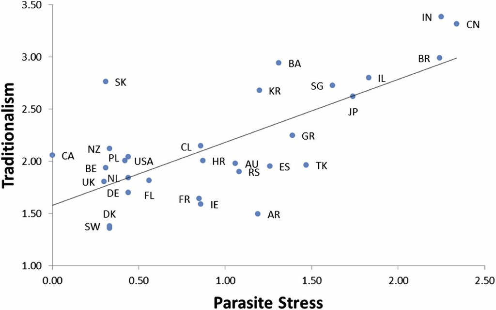

Figure 1.

# import data

## csv

```r
(murray_schaller <- "example_tidy_data/tybur_et_al_data/tabula-murray_schaller_2010_journal_of_cross_cultural_psychology.csv" %>%
  read_csv())
```

```
## # A tibble: 230 x 3
##         Region `9 Items` `7 Items`
##          <chr>     <dbl>     <dbl>
##  1 Afghanistan      0.23      0.15
##  2     Albania     -0.25      0.03
##  3     Algeria      0.47      0.63
##  4     Andorra     -1.08     -1.05
##  5      Angola      0.95      0.93
##  6    Anguilla        NA     -0.27
##  7     Antigua        NA     -0.27
##  8   Argentina     -0.12      0.03
##  9     Armenia      0.10      0.15
## 10       Aruba        NA     -0.28
## # ... with 220 more rows
```

## tsv

```r
(add_health_tsv <- "example_tidy_data/ICPSR_21600/DS0001/21600-0001-Data.tsv" %>%
  read_tsv(.))
```

```
## # A tibble: 6,504 x 2,794
##         AID IMONTH  IDAY IYEAR SCH_YR BIO_SEX VERSION SMP01 SMP03 H1GI1M
##       <int>  <int> <int> <int>  <int>   <int>   <int> <int> <int>  <int>
##  1 57100270      6    23    95      1       2       4     0     1     10
##  2 57101310      5     5    95      1       2       1     1     0     11
##  3 57103171      6    27    95      0       1       4     1     0     10
##  4 57103869      7    14    95      0       1       4     1     0      1
##  5 57104553      7    14    95      1       2       4     1     0      6
##  6 57104649      6    12    95      1       1       3     0     1     12
##  7 57104676      5    31    95      1       1       3     1     0     10
##  8 57109625      6     7    95      1       1       3     1     0      3
##  9 57110897      6    27    95      0       1       4     1     0      9
## 10 57111071      8     3    95      0       1       5     1     0      6
## # ... with 6,494 more rows, and 2784 more variables: H1GI1Y <int>,
## #   H1GI2 <int>, H1GI3 <int>, H1GI4 <int>, H1GI5A <int>, H1GI5B <int>,
## #   H1GI5C <int>, H1GI5D <int>, H1GI5E <int>, H1GI5F <int>, H1GI6A <int>,
## #   H1GI6B <int>, H1GI6C <int>, H1GI6D <int>, H1GI6E <int>, H1GI7A <int>,
## #   H1GI7B <int>, H1GI7C <int>, H1GI7D <int>, H1GI7E <int>, H1GI7F <int>,
## #   H1GI7G <int>, H1GI8 <int>, H1GI9 <int>, H1GI10 <int>, H1GI11 <int>,
## #   H1GI12 <int>, H1GI13M <int>, H1GI13Y <int>, H1GI14 <int>,
## #   H1GI15 <int>, H1GI16M <int>, H1GI16Y <int>, H1GI18 <int>,
## #   H1GI19 <int>, H1GI20 <int>, H1GI21 <int>, H1DA1 <int>, H1DA2 <int>,
## #   H1DA3 <int>, H1DA4 <int>, H1DA5 <int>, H1DA6 <int>, H1DA7 <int>,
## #   H1DA8 <int>, H1DA9 <int>, H1DA10 <int>, H1DA11 <int>, H1GH1 <int>,
## #   H1GH1A <int>, H1GH2 <int>, H1GH3 <int>, H1GH4 <int>, H1GH5 <int>,
## #   H1GH6 <int>, H1GH7 <int>, H1GH8 <int>, H1GH9 <int>, H1GH10 <int>,
## #   H1GH11 <int>, H1GH12 <int>, H1GH13 <int>, H1GH14 <int>, H1GH15 <int>,
## #   H1GH16 <int>, H1GH17 <int>, H1GH18 <int>, H1GH19 <int>, H1GH20 <int>,
## #   H1GH21 <int>, H1GH22 <int>, H1GH23A <int>, H1GH23B <int>,
## #   H1GH23C <int>, H1GH23D <int>, H1GH23E <int>, H1GH23F <int>,
## #   H1GH23G <int>, H1GH23H <int>, H1GH23I <int>, H1GH23J <int>,
## #   H1GH24 <int>, H1GH25 <int>, H1GH26 <int>, H1GH27A <int>,
## #   H1GH27B <int>, H1GH27C <int>, H1GH27D <int>, H1GH27E <int>,
## #   H1GH27F <int>, H1GH27G <int>, H1GH27H <int>, H1GH27I <int>,
## #   H1GH27J <int>, H1GH28 <int>, H1GH29 <int>, H1GH30A <int>,
## #   H1GH30B <int>, H1GH30C <int>, H1GH30D <int>, ...
```

## Excel / xls / xlsx

```r
# note: can also use read_excel()
(tybur_et_al_sO1 <- "example_tidy_data/tybur_et_al_data/pnas.1607398113.sd01.xlsx" %>%
  read_xlsx())
```

```
## # A tibble: 11,501 x 33
##    nation   sex   age  sd01  sd02  sd03  sd04 trad1 trad2 trad3 trad4
##     <dbl> <dbl> <dbl> <dbl> <dbl> <dbl> <dbl> <dbl> <dbl> <dbl> <dbl>
##  1      1     1    30     6     1     6     1     1     1     6     1
##  2      1     1    22     6     1     5     1     1     1     6     1
##  3      1     2    36     5     1     6     1     1     1     6     1
##  4      1     2    24     6     1     6     1     1     1     5     1
##  5      1     2    39     6     1     6     1     2     1     6     1
##  6      1     2    25     5     1     6     1     1     1     6     2
##  7      1     1    25     4     1     5     1     1     1     6     2
##  8      1     1    37     5     1     4     1     1     1     6     1
##  9      1     1    26     6     3     1     1     1     1     5     1
## 10      1     2    26     6     1     6     1     2     1     6     1
## # ... with 11,491 more rows, and 22 more variables: trad5 <dbl>,
## #   trad6 <dbl>, DS1 <dbl>, DS2 <dbl>, DS3 <dbl>, DS4 <dbl>, DS5 <dbl>,
## #   DS6 <dbl>, DS7 <dbl>, sd01r <dbl>, sd03r <dbl>, trad3r <dbl>,
## #   trad5r <dbl>, trad6r <dbl>, HistPath <dbl>,
## #   WHO2012infectiousparasiticdiseasedeathsper1Kpopn <dbl>,
## #   NonzoonoticParasitePrevalence <dbl>, ZoonoticParasitePrevalence <dbl>,
## #   Parasite_PCA <dbl>, SDO <dbl>, Traditionalim <dbl>, DS <dbl>
```

## SPSS / sav

```r
# note: can also use read_spss()
(add_health_sav <- "example_tidy_data/ICPSR_21600/DS0001/21600-0001-Data.sav" %>%
  read_sav())
```

```
## # A tibble: 6,504 x 2,794
##         AID    IMONTH  IDAY     IYEAR    SCH_YR   BIO_SEX   VERSION
##       <chr> <dbl+lbl> <dbl> <dbl+lbl> <dbl+lbl> <dbl+lbl> <chr+lbl>
##  1 57100270         6    23        95         1         2         4
##  2 57101310         5     5        95         1         2         1
##  3 57103171         6    27        95         0         1         4
##  4 57103869         7    14        95         0         1         4
##  5 57104553         7    14        95         1         2         4
##  6 57104649         6    12        95         1         1         3
##  7 57104676         5    31        95         1         1         3
##  8 57109625         6     7        95         1         1         3
##  9 57110897         6    27        95         0         1         4
## 10 57111071         8     3        95         0         1         5
## # ... with 6,494 more rows, and 2787 more variables: SMP01 <dbl+lbl>,
## #   SMP03 <dbl+lbl>, H1GI1M <dbl+lbl>, H1GI1Y <dbl+lbl>, H1GI2 <dbl+lbl>,
## #   H1GI3 <dbl+lbl>, H1GI4 <dbl+lbl>, H1GI5A <dbl+lbl>, H1GI5B <dbl+lbl>,
## #   H1GI5C <dbl+lbl>, H1GI5D <dbl+lbl>, H1GI5E <dbl+lbl>,
## #   H1GI5F <dbl+lbl>, H1GI6A <dbl+lbl>, H1GI6B <dbl+lbl>,
## #   H1GI6C <dbl+lbl>, H1GI6D <dbl+lbl>, H1GI6E <dbl+lbl>,
## #   H1GI7A <dbl+lbl>, H1GI7B <dbl+lbl>, H1GI7C <dbl+lbl>,
## #   H1GI7D <dbl+lbl>, H1GI7E <dbl+lbl>, H1GI7F <dbl+lbl>,
## #   H1GI7G <dbl+lbl>, H1GI8 <dbl+lbl>, H1GI9 <dbl+lbl>, H1GI10 <dbl+lbl>,
## #   H1GI11 <dbl+lbl>, H1GI12 <dbl+lbl>, H1GI13M <dbl+lbl>,
## #   H1GI13Y <dbl+lbl>, H1GI14 <dbl+lbl>, H1GI15 <dbl+lbl>,
## #   H1GI16M <dbl+lbl>, H1GI16Y <dbl+lbl>, H1GI18 <dbl+lbl>,
## #   H1GI19 <dbl+lbl>, H1GI20 <dbl+lbl>, H1GI21 <dbl+lbl>, H1DA1 <dbl+lbl>,
## #   H1DA2 <dbl+lbl>, H1DA3 <dbl+lbl>, H1DA4 <dbl+lbl>, H1DA5 <dbl+lbl>,
## #   H1DA6 <dbl+lbl>, H1DA7 <dbl+lbl>, H1DA8 <dbl+lbl>, H1DA9 <dbl+lbl>,
## #   H1DA10 <dbl+lbl>, H1DA11 <dbl+lbl>, H1GH1 <dbl+lbl>, H1GH1A <dbl+lbl>,
## #   H1GH2 <dbl+lbl>, H1GH3 <dbl+lbl>, H1GH4 <dbl+lbl>, H1GH5 <dbl+lbl>,
## #   H1GH6 <dbl+lbl>, H1GH7 <dbl+lbl>, H1GH8 <dbl+lbl>, H1GH9 <dbl+lbl>,
## #   H1GH10 <dbl+lbl>, H1GH11 <dbl+lbl>, H1GH12 <dbl+lbl>,
## #   H1GH13 <dbl+lbl>, H1GH14 <dbl+lbl>, H1GH15 <dbl+lbl>,
## #   H1GH16 <dbl+lbl>, H1GH17 <dbl+lbl>, H1GH18 <dbl+lbl>,
## #   H1GH19 <dbl+lbl>, H1GH20 <dbl+lbl>, H1GH21 <dbl+lbl>,
## #   H1GH22 <dbl+lbl>, H1GH23A <dbl+lbl>, H1GH23B <dbl+lbl>,
## #   H1GH23C <dbl+lbl>, H1GH23D <dbl+lbl>, H1GH23E <dbl+lbl>,
## #   H1GH23F <dbl+lbl>, H1GH23G <dbl+lbl>, H1GH23H <dbl+lbl>,
## #   H1GH23I <dbl+lbl>, H1GH23J <dbl+lbl>, H1GH24 <dbl+lbl>,
## #   H1GH25 <dbl+lbl>, H1GH26 <dbl+lbl>, H1GH27A <dbl+lbl>,
## #   H1GH27B <dbl+lbl>, H1GH27C <dbl+lbl>, H1GH27D <dbl+lbl>,
## #   H1GH27E <dbl+lbl>, H1GH27F <dbl+lbl>, H1GH27G <dbl+lbl>,
## #   H1GH27H <dbl+lbl>, H1GH27I <dbl+lbl>, H1GH27J <dbl+lbl>,
## #   H1GH28 <dbl+lbl>, H1GH29 <dbl+lbl>, H1GH30A <dbl+lbl>, ...
```

## Stata / dta

```r
# note: can also use read_stata()
(add_health_dta <- "example_tidy_data/ICPSR_21600/DS0001/21600-0001-Data.dta" %>%
  read_dta())
```

```
## # A tibble: 6,504 x 2,794
##         AID    IMONTH  IDAY     IYEAR    SCH_YR   BIO_SEX VERSION
##       <chr> <dbl+lbl> <dbl> <dbl+lbl> <dbl+lbl> <dbl+lbl>   <chr>
##  1 57100270         6    23        95         1         2       4
##  2 57101310         5     5        95         1         2       1
##  3 57103171         6    27        95         0         1       4
##  4 57103869         7    14        95         0         1       4
##  5 57104553         7    14        95         1         2       4
##  6 57104649         6    12        95         1         1       3
##  7 57104676         5    31        95         1         1       3
##  8 57109625         6     7        95         1         1       3
##  9 57110897         6    27        95         0         1       4
## 10 57111071         8     3        95         0         1       5
## # ... with 6,494 more rows, and 2787 more variables: SMP01 <dbl+lbl>,
## #   SMP03 <dbl+lbl>, H1GI1M <dbl+lbl>, H1GI1Y <dbl+lbl>, H1GI2 <dbl+lbl>,
## #   H1GI3 <dbl+lbl>, H1GI4 <dbl+lbl>, H1GI5A <dbl+lbl>, H1GI5B <dbl+lbl>,
## #   H1GI5C <dbl+lbl>, H1GI5D <dbl+lbl>, H1GI5E <dbl+lbl>,
## #   H1GI5F <dbl+lbl>, H1GI6A <dbl+lbl>, H1GI6B <dbl+lbl>,
## #   H1GI6C <dbl+lbl>, H1GI6D <dbl+lbl>, H1GI6E <dbl+lbl>,
## #   H1GI7A <dbl+lbl>, H1GI7B <dbl+lbl>, H1GI7C <dbl+lbl>,
## #   H1GI7D <dbl+lbl>, H1GI7E <dbl+lbl>, H1GI7F <dbl+lbl>,
## #   H1GI7G <dbl+lbl>, H1GI8 <dbl+lbl>, H1GI9 <dbl+lbl>, H1GI10 <dbl+lbl>,
## #   H1GI11 <dbl+lbl>, H1GI12 <dbl+lbl>, H1GI13M <dbl+lbl>,
## #   H1GI13Y <dbl+lbl>, H1GI14 <dbl+lbl>, H1GI15 <dbl+lbl>,
## #   H1GI16M <dbl+lbl>, H1GI16Y <dbl+lbl>, H1GI18 <dbl+lbl>,
## #   H1GI19 <dbl+lbl>, H1GI20 <dbl+lbl>, H1GI21 <dbl+lbl>, H1DA1 <dbl+lbl>,
## #   H1DA2 <dbl+lbl>, H1DA3 <dbl+lbl>, H1DA4 <dbl+lbl>, H1DA5 <dbl+lbl>,
## #   H1DA6 <dbl+lbl>, H1DA7 <dbl+lbl>, H1DA8 <dbl+lbl>, H1DA9 <dbl+lbl>,
## #   H1DA10 <dbl+lbl>, H1DA11 <dbl+lbl>, H1GH1 <dbl+lbl>, H1GH1A <dbl+lbl>,
## #   H1GH2 <dbl+lbl>, H1GH3 <dbl+lbl>, H1GH4 <dbl+lbl>, H1GH5 <dbl+lbl>,
## #   H1GH6 <dbl+lbl>, H1GH7 <dbl+lbl>, H1GH8 <dbl+lbl>, H1GH9 <dbl+lbl>,
## #   H1GH10 <dbl+lbl>, H1GH11 <dbl+lbl>, H1GH12 <dbl+lbl>,
## #   H1GH13 <dbl+lbl>, H1GH14 <dbl+lbl>, H1GH15 <dbl+lbl>,
## #   H1GH16 <dbl+lbl>, H1GH17 <dbl+lbl>, H1GH18 <dbl+lbl>,
## #   H1GH19 <dbl+lbl>, H1GH20 <dbl+lbl>, H1GH21 <dbl+lbl>,
## #   H1GH22 <dbl+lbl>, H1GH23A <dbl+lbl>, H1GH23B <dbl+lbl>,
## #   H1GH23C <dbl+lbl>, H1GH23D <dbl+lbl>, H1GH23E <dbl+lbl>,
## #   H1GH23F <dbl+lbl>, H1GH23G <dbl+lbl>, H1GH23H <dbl+lbl>,
## #   H1GH23I <dbl+lbl>, H1GH23J <dbl+lbl>, H1GH24 <dbl+lbl>,
## #   H1GH25 <dbl+lbl>, H1GH26 <dbl+lbl>, H1GH27A <dbl+lbl>,
## #   H1GH27B <dbl+lbl>, H1GH27C <dbl+lbl>, H1GH27D <dbl+lbl>,
## #   H1GH27E <dbl+lbl>, H1GH27F <dbl+lbl>, H1GH27G <dbl+lbl>,
## #   H1GH27H <dbl+lbl>, H1GH27I <dbl+lbl>, H1GH27J <dbl+lbl>,
## #   H1GH28 <dbl+lbl>, H1GH29 <dbl+lbl>, H1GH30A <dbl+lbl>, ...
```